# 1AI

ABT-MSE Operating model fitting report

Tom Carruthers

November 28, 2018

# 1 Operating model scenario

less Fmod

# 2 Area definitions

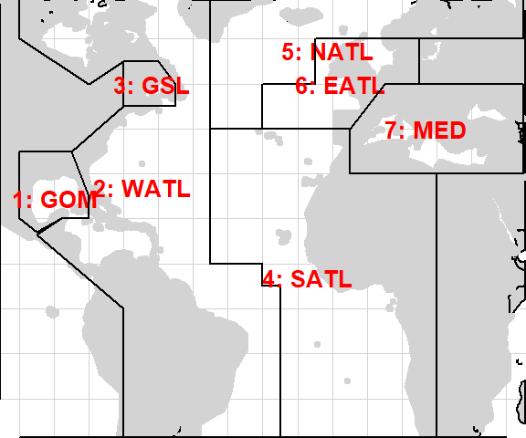

Figure 1. Area definitions for operating model

# 3 Fits to CPUE indices

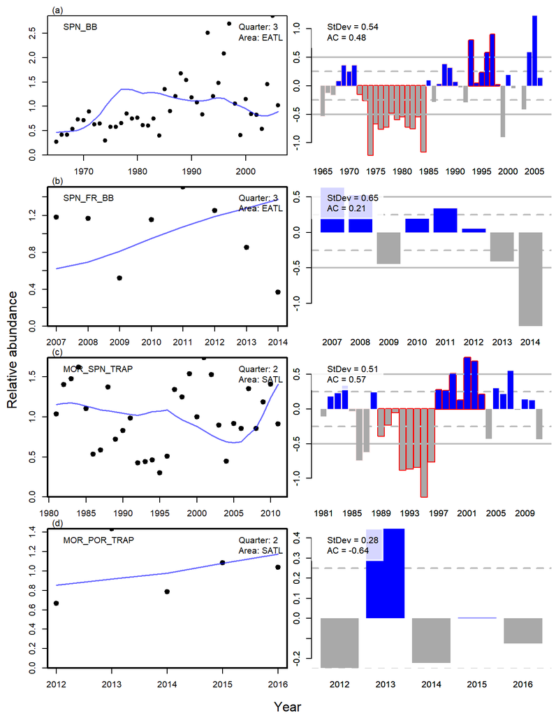

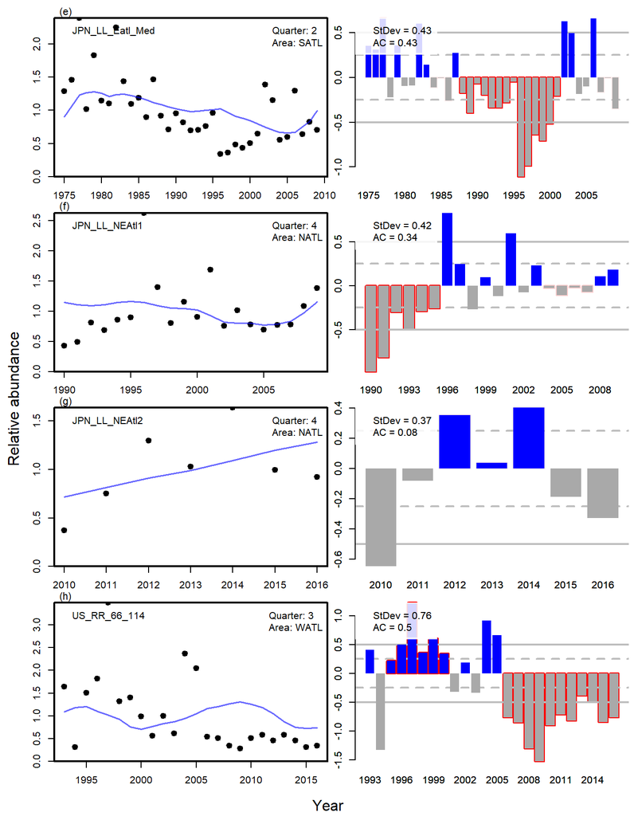

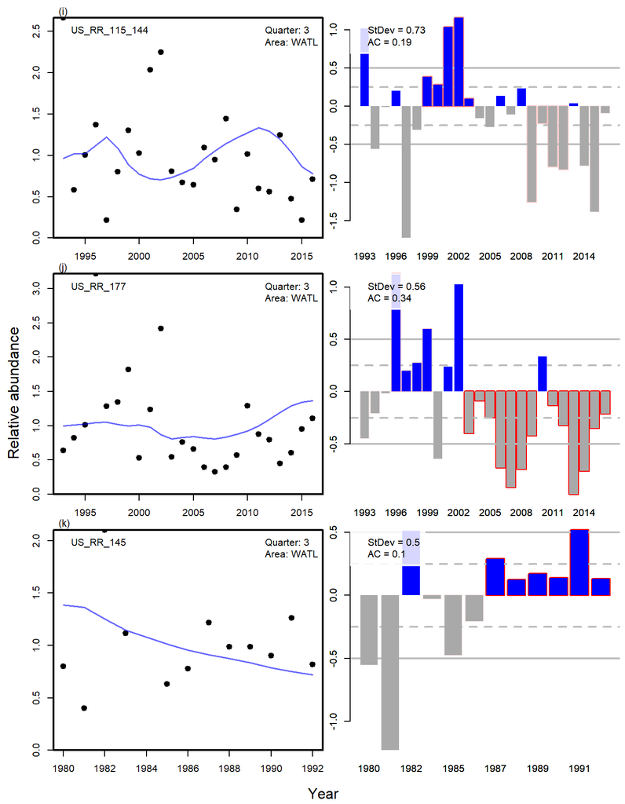

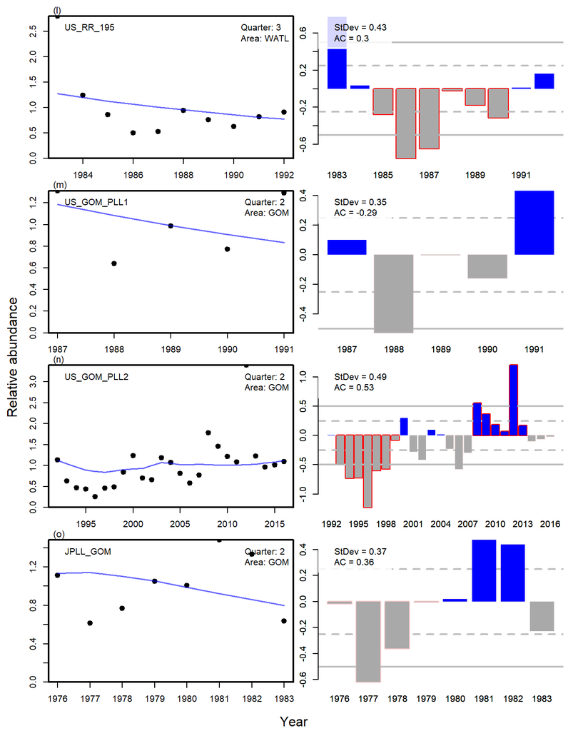

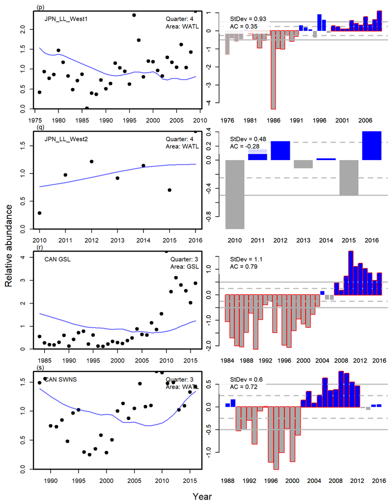

Figure 2. Operating model fits to CPUE indices. Each row corresponds with an index. The left-hand panels show the normalized (log index has mean 0) observed (black dots) and model predicted (blue line) indices. The right-hand panels show the log devitations (the observation model is log-normal) including the residual standard deviation (StDev) and lag-1 autocorrelation in residuals (AC). Runs of positive or negative residuals are highlighted with a red border. The dashed and solid horizontal grey lines are the same on each plot - the scale of y-axis varies among indices for these plots.

# 4 Fits to FI indices

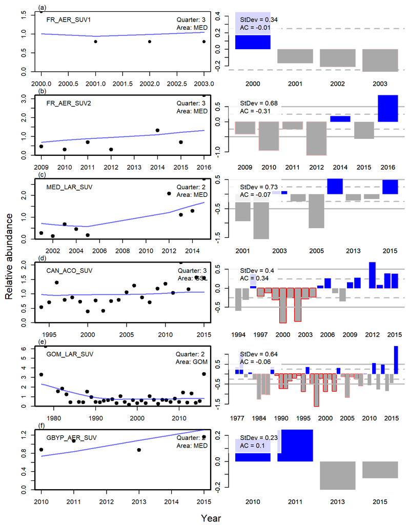

Figure 3. Operating model fits to fishery-independent indices. Each row corresponds with an index. The left-hand panels show the normalized (log index has mean 0) observed (black dots) and model predicted (blue line) indices. The right-hand panels show the log devitations (the observation model is log-normal) including the residual standard deviation (StDev) and lag-1 autocorrelation in residuals (AC). Runs of positive or negative residuals are highlighted with a red border. The dashed and solid horizontal grey lines are the same on each plot - the scale of y-axis varies among indices for these plots.

# 5 Spawning biomass

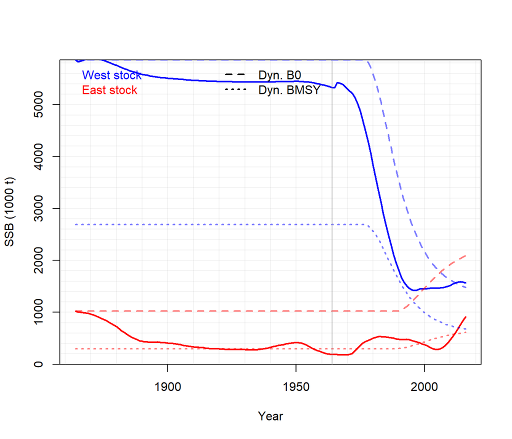

Figure 4a. Historical spawning biomass. Dynamic unfished spawning biomass (Dyn. B0) is calculated using year-specific estimates of recruitment strength assuming that there was zero fishing (ie it lags shifts in productivity). Dynamic BMSY is a fixed fraction of B0 based on the most recent estimates of BMSY relative to unfished.

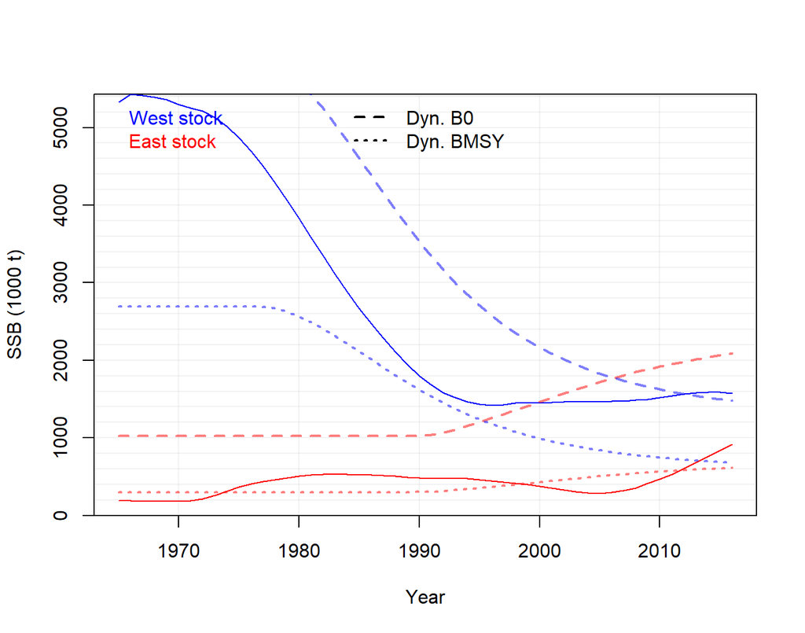

Figure 4b. Recent spawning biomass. Dynamic unfished spawning biomass (Dyn. B0) is calculated using year-specific estimates of recruitment strength assuming that there was zero fishing (ie it lags shifts in productivity). Dynamic BMSY is a fixed fraction of B0 based on the most recent estimates of BMSY relative to unfished.

# 6 Assessment comparison

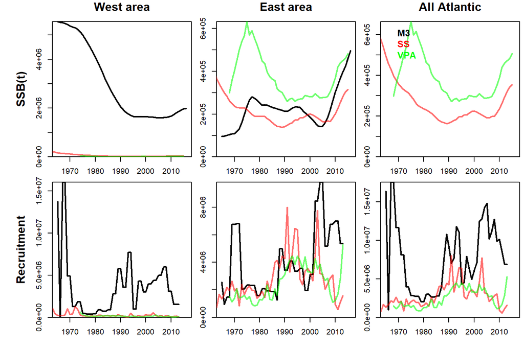

Figure 5. Regional comparisons (45deg W) with 2017 stock assessment. Note that annual estimates from the operating model are calculated from average of the seasonal predictions.

# 7 Stock-recruitment relationships

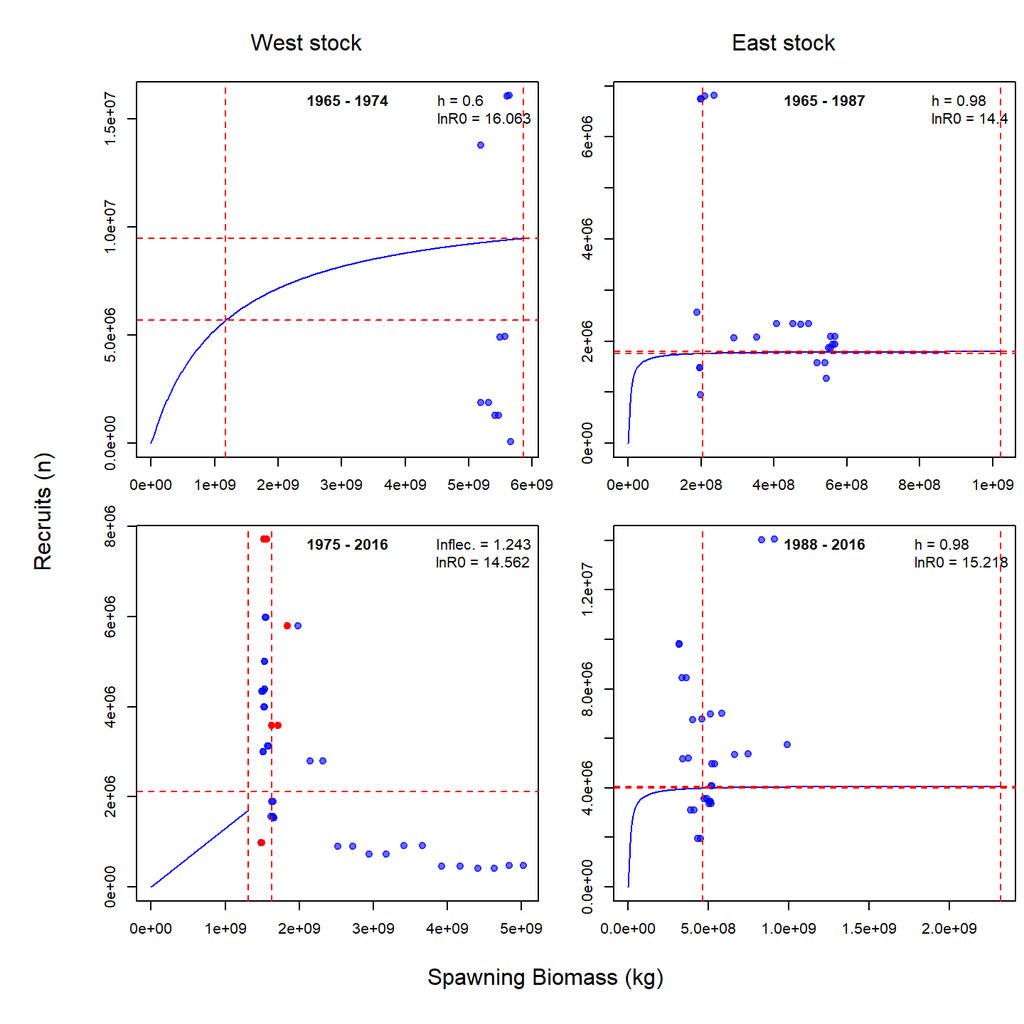

Figure 6. Model predicted spawning stock biomass and recruitment. h is the assumed value of steepness, lnR0 is the log unfished recruitment. In the case of the hockey stick SR model, Inflec. is the biomass position of the inflection (join) point relative to unfished.Hockey-stick stock-recruitment curves define the inflection point as the mean biomass in the range of 1990-1995, and these depicted by red points.

# 8 MSY reference points

Table 1a. 2016 Reference points by area. MSY and BMSY numbers are in tons. Biomass figures (BMSY, B0) refer to Spawning Stock Biomass. Stock depletion refers to spawning stock biomass relative to ‘dynamic B0’ (a running calculation of unfished stock size accounting for shifts in recruitment). Similarly, BMSY is calculated as a dynamic quantity relating to ‘dynamic B0’.

|  | MSY | BMSY | BMSY_B0 | B_BMSY | Dep |
| --- | --- | --- | --- | --- | --- |
| East area | 40458 | 430458 | 0.296 | 1.243 | 0.441 |
| West area | 41504 | 1007711 | 0.423 | 2.027 | 0.925 |

Table 1b. 2016 Reference points by stock. MSY and BMSY numbers are in tons. Biomass figures (BMSY, B0) refer to Spawning Stock Biomass. Fishing rate figures (FMSY, F) are phrased as apical Fs (F on the most selected length class). Stock depletion refers to spawning stock biomass relative to ‘dynamic B0’ (a running calculation of unfished stock size accounting for shifts in recruitment). Similarly BMSY is calculated as a dynamic quantity relating to ‘dynamic B0’.

|  | MSY | FMSY | BMSY | BMSY_B0 | F_FMSY | B_BMSY | Dep |
| --- | --- | --- | --- | --- | --- | --- | --- |
| East stock | 69665 | 0.154 | 739185 | 0.295 | 0.125 | 1.238 | 0.438 |
| West stock | 12297 | 0.026 | 698984 | 0.459 | 0.738 | 2.247 | 1.060 |

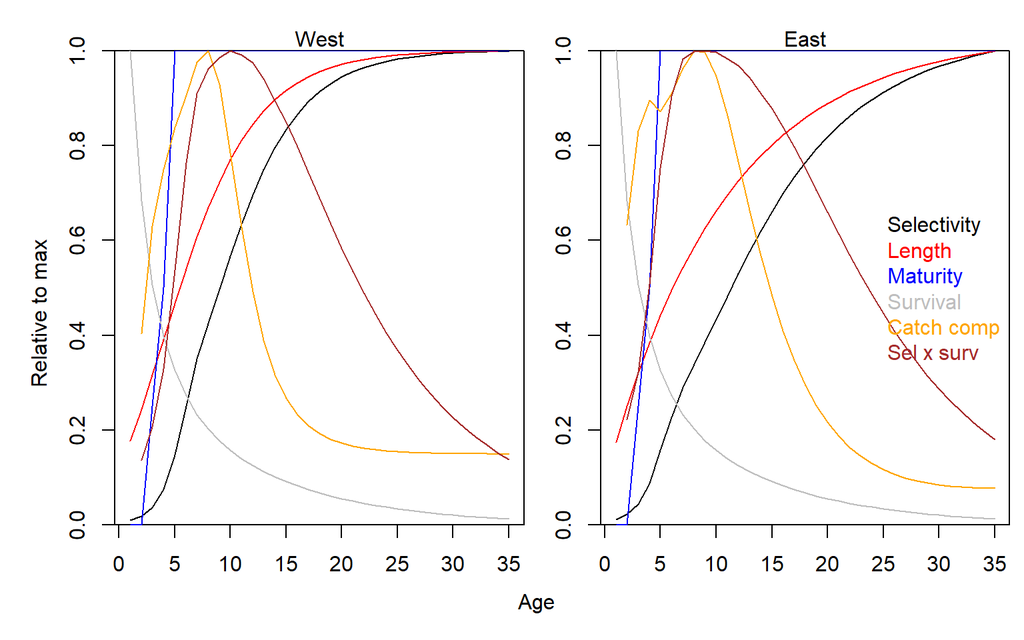

Figure 7. Age-specific quantities determining 2016 MSY reference points. Survival is based on natural mortality only. Catch comp (orange line) is the age composition of all catch at length data (converted to age via an ALK). Sel x surv is the unfished predicted age composition of catches based on 2016 selectivity (black line) and unfished age structure from survival (grey line). Sel x surv (brown line) provides an approximate check of the model approximation of catch composition. The sel x surv should be of higher age (to the right of) the catch comp that is from an exploited population.

# 9 Current F-at-age profile

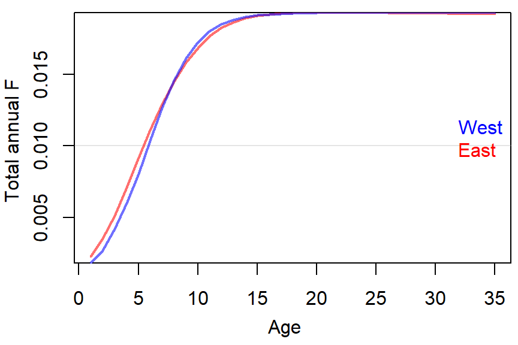

Figure 8. The current profile of F at age summed over all fleets, average weighed (by total contribution to annual F) over seasons and areas.

# 10 Estimated size selectivity

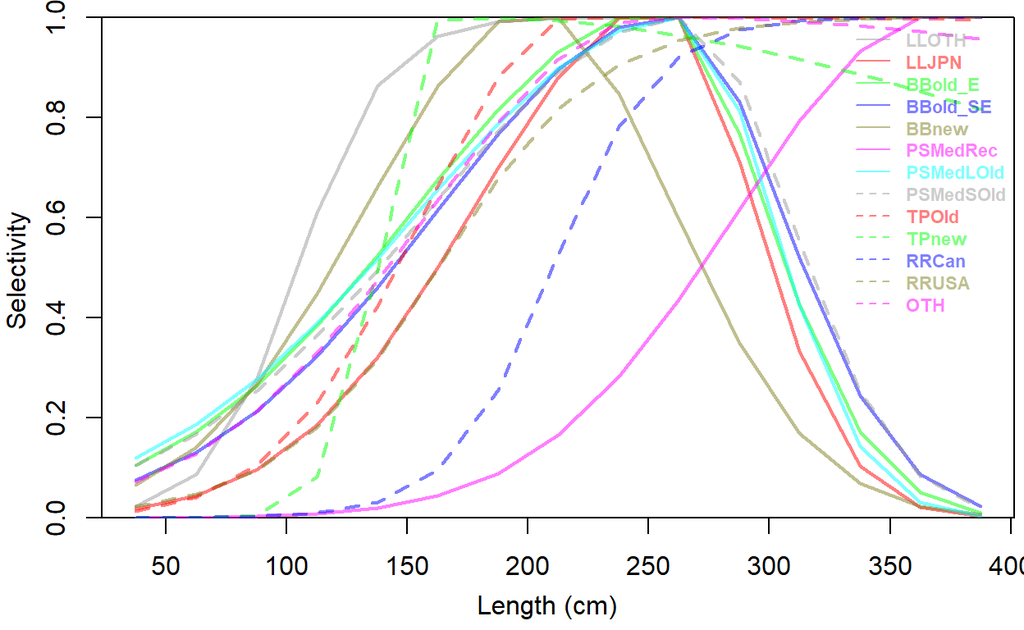

Figure 9. The size selectivity of the various fishing fleets included in the operating model.

# 11 Fit to aggregate catches

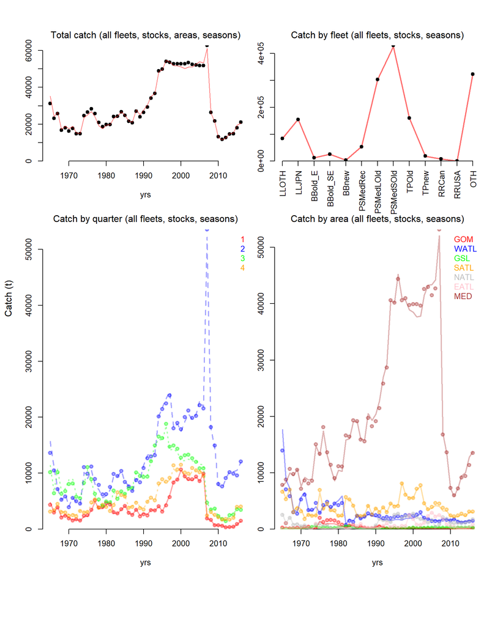

Figure 10. Fit to a observed total catches (tons) aggregated over various axes (lines = predicted, points = observed)

# 12 Fit to length composition

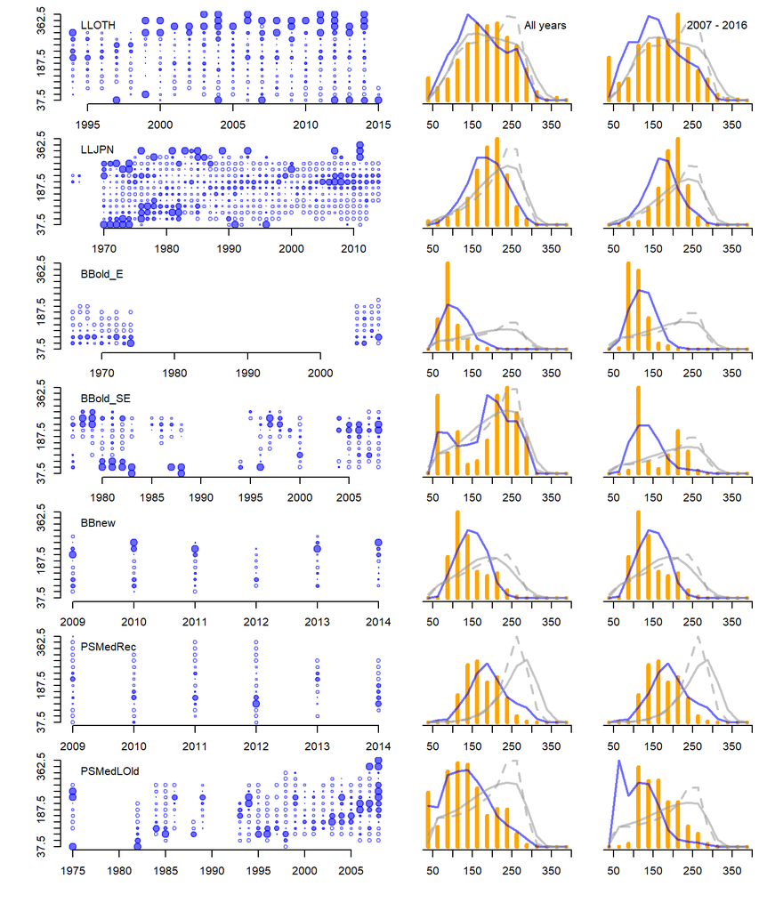

Figure 11a.Length composition residuals. Filled blue points are positive Pearson residuals (observed is higher than predicted), blue circles are negative residuals (observed is lower than predicted). Orange bars are observed, blue lines are model predictions. Grey lines show the predicted unfished composition of the Eastern stock (solid grey line) and the Western stocks (dashed grey line).

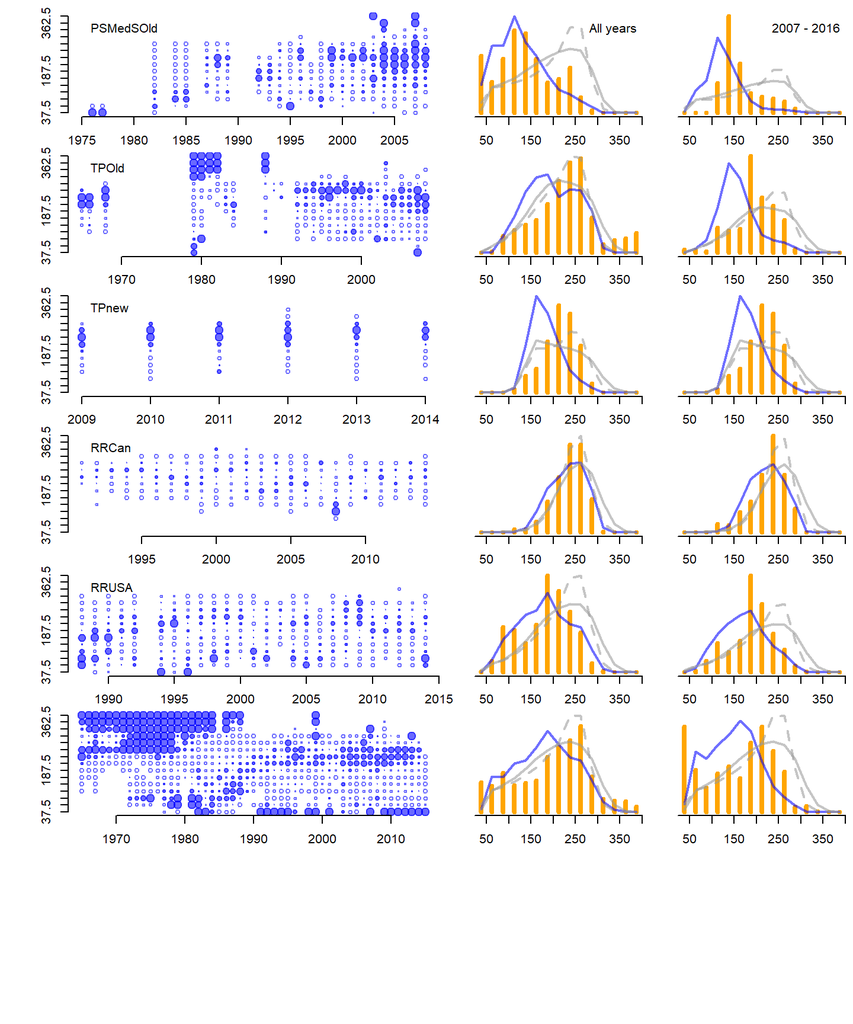

Figure 11b.Length composition residuals. Filled blue points are positive Pearson residuals (observed is higher than predicted), blue circles are negative residuals (observed is lower than predicted). Orange bars are observed, blue lines are model predictions. Grey lines show the predicted unfished composition of the Eastern stock (solid grey line) and the Western stocks (dashed grey line).

# 13 Spatial distribution

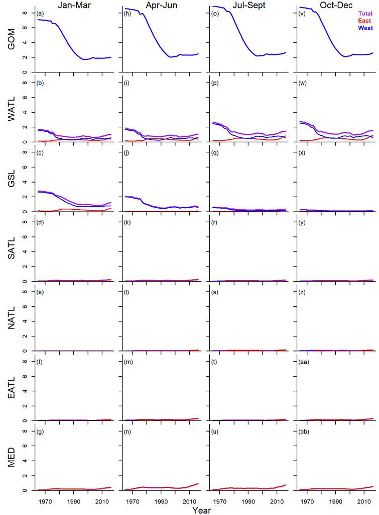

Figure 12. The predicted seasonal and spatial biomass of Atlantic bluefin tuna by stock.

# 14 Estimated unfished movement

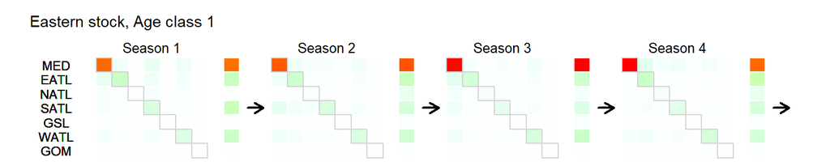

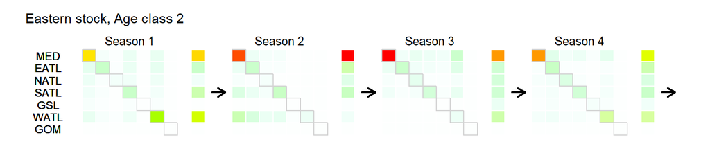

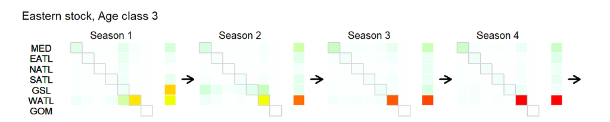

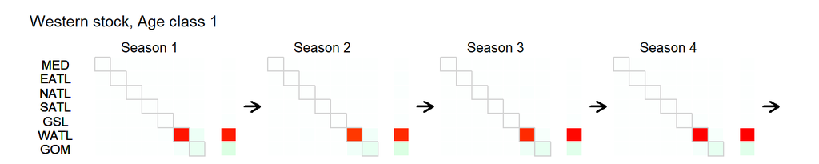

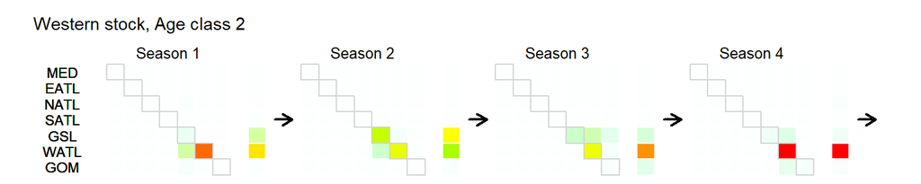

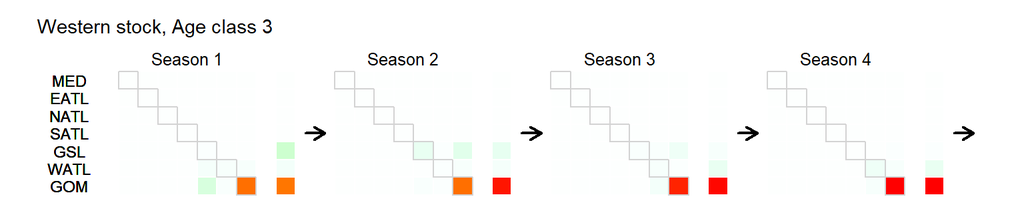

Figure 13. The implied asymptotic distribution of fish under unfished conditions (red-orange-green-white, more to less)

# 15 Fit to stock-of-origin data

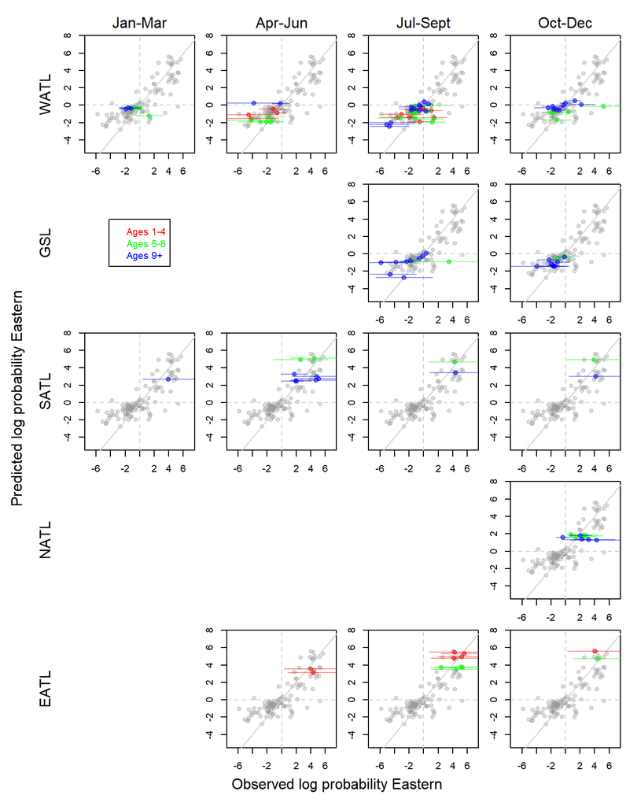

Figure 14. The model fit to the observed probability eastern stock of origin data. The data were dervied by the mixture modelling approach of Carruthers and Butterworth where the ‘signature’ of Western (GOM) and Eastern (Med) genetics and microchemistry assignment data are used to derive an estimate of the stock composition in for fish of a given age class, in a given year, area and season. The horizontal lines represent the 90% confidence interval for the observed data. Grey points are all of the data and are the same in each plot. The colored points and bars are specific to each panel. Green-red-blue colors represent age classes.

# 16 Fit to e-tag transitions

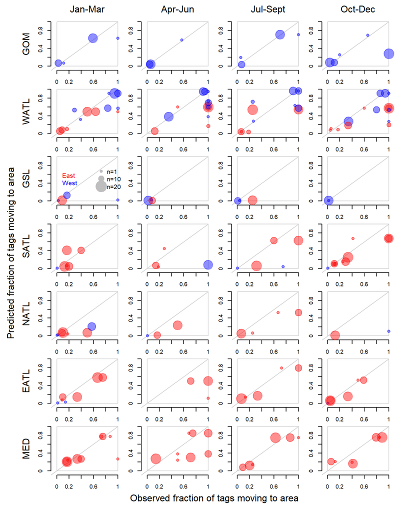

Figure 15. The model fit to the observed fractions of tags moving to the various areas by season. Red / blue points represent observed fraction of eastern / western fish moving to an area, respectively. The size of the bubble represents the number of tags moving.

# 17 Stock mixing

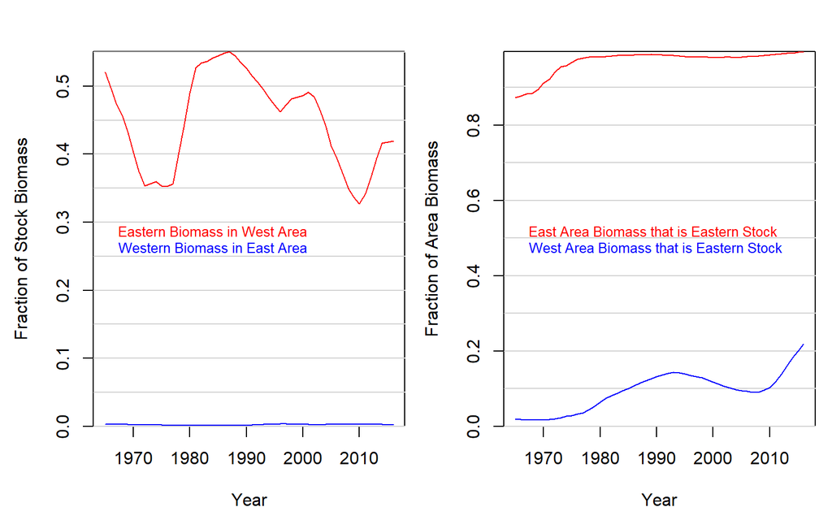

Figure 16. Predicted stock mixing. On the left is the degree to which each stock has been distributed in the opposite ocean area over time. One the right is the fraction of Eastern Stock biomass found in the East/West areas over time (stock composition over time).